# "I'm not a robot": Aplicação de uma arquitetura autoral de Redes Convolucionais (cNN) para a automatização do problema de reconhecimento de Captcha

### 12 de dezembro de 2022

André Luiz Moreira Dutra - 2019006345  
Marcos Vinicius Caldeira Pacheco - 2019006957  
Pedro Dias Pires - 2019007040

# Introdução

O objetivo deste trabalho é desenvolver um método que seja capaz de reconhecer corretamente os caracteres presentes em imagens captchas. Foi disponibilizado um conjunto de dados de imagens dividido em treino, validação e teste, junto com a resposta correta de todos os casos. Foi desenvolvida, então, uma rede neural convolucional que se mostrou capaz de identificar todos os seis caracteres em aproximadamente 65% dos casos.

# Instalação e importação dos Módulos utilizados

```python
#Comandos de instalação
!pip install tensorflow
!pip install opencv-python
!pip install numpy
!pip install matplotlib
```

```python
import os
os.environ['TF_CPP_MIN_LOG_LEVEL'] = '2' # Desabilitando mensagens de informação/warning do Tensorflow
import string
import numpy as np
import matplotlib.pyplot as plt
import cv2
import tensorflow as tf
```

# Leitura dos dados

```python
DATA_PATH = "./dados/CAPTCHA-10k/"
LABELS_DIRECTORY = "labels10k"
TRAIN_DIRECTORY = "treinamento"
VALIDATION_DIRECTORY = "validacao"
TEST_DIRECTORY = "teste"

# Fazendo a leitura dos labels associados às imagens do CAPTCHA
labels = []
for label_file_name in sorted(os.listdir(os.path.join(DATA_PATH, LABELS_DIRECTORY))):
    with open(os.path.join(DATA_PATH, LABELS_DIRECTORY, label_file_name), 'r') as label_file:
        labels.append(label_file.read().strip())
print(f"Foram carregados {len(labels)} labels!")

def read_data(subdirectory: str, labels: list[str]) -> tuple[np.ndarray, np.ndarray]:
    """
    Essa função é responsável por realizar a leitura das imagens e associá-las
    aos labels dados na lista "labels". A função recebe uma string que aponta
    para o subdiretório do diretório do dataset que contém as imagens e um vetor
    contendo os labels associados a cada imagem pelo nome do arquivo. São
    retornados um tensor X (como um array numpy), contendo as imagens lidas, um
    vetor y (como um array numpy) com os labels (strings) correspondentes a cada
    imagem
    """
    X = []
    y = []
    for image_file_name in os.listdir(os.path.join(DATA_PATH, subdirectory)):
        image = cv2.imread(os.path.join(DATA_PATH, subdirectory, image_file_name))
        # Convertendo a imagem para escala de cinza, eliminando canais redundantes (as imagens do
        # dataset não são coloridas). Apesar disso, a imagem ainda continua representa como um
        # tensor 3D para compatibilidade com o Tensorflow
        image = np.expand_dims(cv2.cvtColor(image, cv2.COLOR_BGR2GRAY), 2)
        X.append(image)
        # Encontrando o label corresponde à imagem a partir do nome
        label_index = int(os.path.splitext(image_file_name)[0]) - 1
        y.append(labels[label_index])
    X = np.array(X)
    y = np.array(y)
    return X, y

# Fazendo a leitura dos dados de treino, teste e validação
X_train, y_train_labels = read_data(TRAIN_DIRECTORY, labels)
X_validation, y_validation_labels = read_data(VALIDATION_DIRECTORY, labels)
X_test, y_test_labels = read_data(TEST_DIRECTORY, labels)
print(f"Dimensões dos dados de treino: {X_train.shape}\nDimensões dos labels de treino: {y_train_labels.shape}")
print(f"Dimensões dos dados de validação: {X_validation.shape}\nDimensões dos labels de validação: {y_validation_labels.shape}")
print(f"Dimensões dos dados de teste: {X_test.shape}\nDimensões dos labels de teste: {y_test_labels.shape}")
```

```
Foram carregados 10000 labels!
Dimensões dos dados de treino: (8000, 50, 180, 1)
Dimensões dos labels de treino: (8000,)
Dimensões dos dados de validação: (1000, 50, 180, 1)
Dimensões dos labels de validação: (1000,)
Dimensões dos dados de teste: (1000, 50, 180, 1)
Dimensões dos labels de teste: (1000,)
```

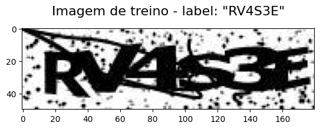

```python
# Exibindo uma imagem do conjunto de treino e seu respectivo label
plt.imshow(X_train[0], cmap='gray')
plt.title(f'Imagem de treino - label: "{y_train_labels[0]}"', fontsize=16, pad=16);
```

# Pré-processamento das entradas da rede

```python
# Definindo os caracteres de saída possíveis e o tamanho da string de saída
POSSIBLE_OUTPUTS = string.ascii_uppercase + string.digits
OUTPUT_LENGTH = 6
print(f"Número de caracteres de saída: {OUTPUT_LENGTH}\nCaracteres de saída possíveis ({len(POSSIBLE_OUTPUTS)} possibilidades): {POSSIBLE_OUTPUTS}")

def process_label(input_str: str) -> np.ndarray:
    """
    Essa função mapeia uma string de entrada a uma matriz cujas linhas representam
    cada caractere que faz parte da saída e as colunas representam cada caractere
    possível. Essa matriz corresponde à saída gerada pela rede convolucional que
    reconhece os caracteres do CAPTCHA
    """
    category_map = dict(zip(POSSIBLE_OUTPUTS, range(len(POSSIBLE_OUTPUTS))))
    output = np.zeros((OUTPUT_LENGTH, len(POSSIBLE_OUTPUTS)))
    for i, char in enumerate(input_str):
        output[i, category_map[char]] = 1
    return output

def process_output_matrix(output_matrix: np.ndarray) -> str:
    """
    Essa função produz uma string a partir de uma matriz de saída gerada pela
    rede convolucional. O mapeamento é feito considerando, para cada posição da
    saída, qual o caractere mais provável para aquela posição (isto é, aquele
    com a maior resposta)
    """
    output_str = ""
    for i in range(OUTPUT_LENGTH):
        output_str += POSSIBLE_OUTPUTS[np.argmax(output_matrix[i, :])]
    return output_str

def preprocess_input(images: np.ndarray, labels: np.ndarray) -> tuple[np.ndarray, np.ndarray, np.ndarray]:
    """
    Essa função realiza o pré-processamento dos conjuntos de imagens de entrada
    e seus respectivos labels para os formatos utilizados pela rede
    convolucional que será treinada. A função também ignora pares imagem-label
    cuja saída possui um tamanho diferente do especificado (variável
    OUTPUT_LENGTH). São retornados um tensor com as imagens no formato de
    entrada da rede, uma matriz com as saídas no formato da rede e um vetor com
    as strings de saída correspondentes (após a remoção das imagens ignoradas)
    """
    y = []
    ignored_indexes = [] # Salvando os índices das entradas a serem ignoradas
    for i, label in enumerate(labels):
        # O caractere "?" é usado nos labels dataset para representar uma posição vazia e, sendo assim, deve ser eliminado
        label = label.replace('?', '')
        if len(label) != OUTPUT_LENGTH: # Ignorando saídas de tamanho diferente do padrão
            ignored_indexes.append(i)
            continue
        y.append(process_label(label))
    # Alterando o formato dos labels para uma lista de matrizes, com cada posição correspondendo a todos os labels para
    # apenas um  dos caracteres da saída (que corresponde a uma das camadas de saída da rede)
    y = np.array(y).transpose(1, 0, 2)
    # Removendo imagens ignoradas do conjunto de dados
    X = np.delete(images, ignored_indexes, axis=0)
    # Removendo os labels (strings) associadas às imagens ignoradas
    labels = np.delete(labels, ignored_indexes, axis=0)
    return X, y, labels

def process_output(output: list[np.ndarray]):# -> np.ndarray[str]:
    output_tensor = np.array(output).transpose(1, 0, 2)
    y_labels = []
    for i in range(output_tensor.shape[0]):
        y_labels.append(process_output_matrix(output_tensor[i, :, :]))
    return np.array(y_labels)

X_train, y_train, y_train_labels = preprocess_input(X_train, y_train_labels)
X_validation, y_validation, y_validation_labels = preprocess_input(X_validation, y_validation_labels)
X_test, y_test, y_test_labels = preprocess_input(X_test, y_test_labels)
print(f"Dimensão das saídas de treino: {y_train.shape}")
print(f"Dimensão das saídas de validação: {y_validation.shape}")
print(f"Dimensão das saídas de teste: {y_test.shape}")
```

```
Número de caracteres de saída: 6
Caracteres de saída possíveis (36 possibilidades): ABCDEFGHIJKLMNOPQRSTUVWXYZ0123456789
Dimensão das saídas de treino: (6, 7899, 36)
Dimensão das saídas de validação: (6, 999, 36)
Dimensão das saídas de teste: (6, 999, 36)
```

# Definição da arquitetura da rede

A rede foi definida com seis camadas convolucionais, cujo resultado é agregado em um descritor que é passado para as camadas fully connected. Estas, por sua vez, se distribuem em seis conjuntos de duas camadas fully connected cada. Cada conjunto gera o resultado de um dos caracteres, com os seis conjuntos gerando a matriz de previsão do string completo representado na imagem.

Das seis camadas convolucionais, as duas primeiras possuem núcleos de tamanho 5x5, tendo 20 e 32 neurônios respectivamente, e um max-pooling entre elas. Observe que o tamanho do núcleo foi mantido após o max-pooling, para capturar relações mais distantes entre pontos nos feature maps. Após a segunda camada, é feito mais um max pooling e o fluxo segue para a próxima camada.

A terceira, a quarta, a quinta e a sexta camadas possuem núcleos de tamanho 3x3, tendo 32, e as demais 16 neurônios, respectivamente. Entre a quarta e a quinta camadas é feita uma normalização dos dados e um max pooling. Ao fim da sexta camada, os feature maps são agregados em um descritor, que é passado então para as camadas fully connected.

As camadas fully connected são divididas em seis conjuntos de duas camadas cada, sendo uma camada densa e uma camada de saída, junto com uma operação de dropout que tenta evitar overfitting. A camada densa é uma camada completa da rede com 64 neurônios. Já a operação de dropout seleciona aleatoriamente 50% dos resultados da camada anterior e os ignora, setando-os para 0, para evitar overfitting, forçando a rede a aprender mais de um "caminho" nos neurônios. Por fim, a camada de saída possui um neurônio para cada caractere de saída possível, todos os caracteres e dígitos, e representa em suas posições a probabilidade de uma posição da saída conter um determinado caractere. Com os seis conjuntos de duas camadas fully connected, é gerada uma matriz de probabilidades que é convertida em um string utilizando as funções de pós-processamento definidas anteriormente.

```python
def build_model(image_shape: tuple) -> tf.keras.Model:
    """
    Essa função constrói a rede convolucional utilizada para reconhecer os caracteres do CAPTCHA.
    A rede é construída camada a camada utilizando a API funcional da biblioteca Keras. A função
    retorna um modelo do Keras (classe keras.Model)
    """
    input_layer = tf.keras.layers.Input(shape=image_shape)
    conv1 = tf.keras.layers.Conv2D(20, kernel_size=(5, 5), padding="same", activation="relu")(input_layer)
    pooling1 = tf.keras.layers.MaxPooling2D(padding="same")(conv1)
    conv2 = tf.keras.layers.Conv2D(32, kernel_size=(5, 5), padding="same", activation="relu")(pooling1)
    pooling2 = tf.keras.layers.MaxPooling2D(padding="same")(conv2)
    conv3 = tf.keras.layers.Conv2D(32, kernel_size=(3, 3), padding="same", activation="relu")(pooling2)
    conv4 = tf.keras.layers.Conv2D(16, kernel_size=(3, 3), padding="same", activation="relu")(conv3)
    batch_norm = tf.keras.layers.BatchNormalization()(conv4)
    pooling3 = tf.keras.layers.MaxPooling2D(padding="same")(batch_norm)
    conv5 = tf.keras.layers.Conv2D(16, kernel_size=(3, 3), padding="same", activation="relu")(pooling3)
    conv6 = tf.keras.layers.Conv2D(16, kernel_size=(3, 3), padding="same", activation="relu")(conv5)
    descriptor = tf.keras.layers.Flatten()(conv6)
    # Criando redes fully connected espelhadas para determinar cada um dos caracteres de saída
    decision_layers = []
    for i in range(OUTPUT_LENGTH):
        dense1 = tf.keras.layers.Dense(64, activation='relu')(descriptor)
        dropout = tf.keras.layers.Dropout(rate=0.5)(dense1)
        output = tf.keras.layers.Dense(len(POSSIBLE_OUTPUTS), activation='sigmoid')(dropout)
        decision_layers.append(output)
    return tf.keras.Model(input_layer, decision_layers)

model = build_model((50, 180, 1))
# Compilando o modelo construído e exibindo um sumário de suas camadas e parâmetros
model.compile(loss="categorical_crossentropy", optimizer="adam", metrics=["accuracy"])
model.summary()
```

```
Model: "model"
__________________________________________________________________________________________________
 Layer (type)                   Output Shape         Param #     Connected to
==================================================================================================
 input_1 (InputLayer)           [(None, 50, 180, 1)  0           []
                                ]

 conv2d (Conv2D)                (None, 50, 180, 20)  520         ['input_1[0][0]']

 max_pooling2d (MaxPooling2D)   (None, 25, 90, 20)   0           ['conv2d[0][0]']

 conv2d_1 (Conv2D)              (None, 25, 90, 32)   16032       ['max_pooling2d[0][0]']

 max_pooling2d_1 (MaxPooling2D)  (None, 13, 45, 32)  0           ['conv2d_1[0][0]']

 conv2d_2 (Conv2D)              (None, 13, 45, 32)   9248        ['max_pooling2d_1[0][0]']

 conv2d_3 (Conv2D)              (None, 13, 45, 16)   4624        ['conv2d_2[0][0]']

 batch_normalization (BatchNorm  (None, 13, 45, 16)  64          ['conv2d_3[0][0]']
 alization)

 max_pooling2d_2 (MaxPooling2D)  (None, 7, 23, 16)   0           ['batch_normalization[0][0]']

 conv2d_4 (Conv2D)              (None, 7, 23, 16)    2320        ['max_pooling2d_2[0][0]']

 conv2d_5 (Conv2D)              (None, 7, 23, 16)    2320        ['conv2d_4[0][0]']

 flatten (Flatten)              (None, 2576)         0           ['conv2d_5[0][0]']

 dense (Dense)                  (None, 64)           164928      ['flatten[0][0]']

 dense_2 (Dense)                (None, 64)           164928      ['flatten[0][0]']

 dense_4 (Dense)                (None, 64)           164928      ['flatten[0][0]']

 dense_6 (Dense)                (None, 64)           164928      ['flatten[0][0]']

 dense_8 (Dense)                (None, 64)           164928      ['flatten[0][0]']

```

[output cut: 16 more lines]

```
 dense_3 (Dense)                (None, 36)           2340        ['dropout_1[0][0]']

 dense_5 (Dense)                (None, 36)           2340        ['dropout_2[0][0]']

 dense_7 (Dense)                (None, 36)           2340        ['dropout_3[0][0]']

 dense_9 (Dense)                (None, 36)           2340        ['dropout_4[0][0]']

 dense_11 (Dense)               (None, 36)           2340        ['dropout_5[0][0]']

==================================================================================================
Total params: 1,038,736
Trainable params: 1,038,704
Non-trainable params: 32
__________________________________________________________________________________________________
```

# Treinamento do modelo gerado

```python
history = model.fit(X_train, list(y_train), validation_data=(X_validation, list(y_validation)), batch_size=32, epochs=50)
```

## Comportamento no treino

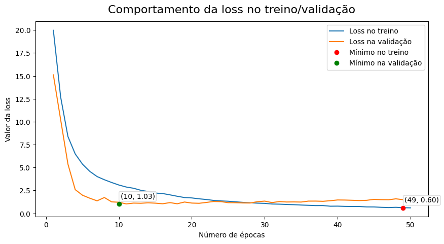

```python
n_epochs =  history.params['epochs']
epochs = np.arange(1, n_epochs + 1)
min_loss = np.min(history.history['loss'])
min_loss_epoch = np.argmin(history.history['loss'])
min_val_loss = np.min(history.history['val_loss'])
min_val_loss_epoch = np.argmin(history.history['val_loss'])
plt.figure(figsize=(10, 5))
plt.title(f"Comportamento da loss no treino/validação", fontsize=16, pad=12)
plt.xlabel("Número de épocas")
plt.ylabel("Valor da loss")
plt.plot(epochs, history.history['loss'], label="Loss no treino")
plt.plot(epochs, history.history['val_loss'], label="Loss na validação")
plt.plot(min_loss_epoch, min_loss, "ro", label="Mínimo no treino")
plt.plot(min_val_loss_epoch, min_val_loss, "go", label="Mínimo na validação")
plt.text(min_loss_epoch + 0.2, min_loss + 0.6, f"({min_loss_epoch}, {min_loss:.2f})", bbox=dict(boxstyle="round,pad=0.2", fc='white', ec='#D7D7D7', alpha=.92))
plt.text(min_val_loss_epoch + 0.2, min_val_loss + 0.6, f"({min_val_loss_epoch}, {min_val_loss:.2f})", bbox=dict(boxstyle="round,pad=0.2", fc='white', ec='#D7D7D7', alpha=.92))
plt.legend();
```

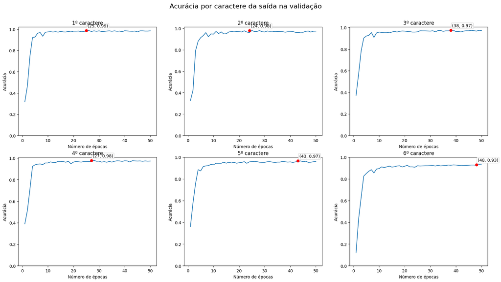

```python
fig, ax = plt.subplots(2, 3)
fig.set_size_inches((20, 10))
fig.suptitle("Acurácia por caractere da saída na validação", size=16)
fig.subplots_adjust(top=0.9)
ticks = np.arange(0, 1.2, 0.2)
for out_pos, out_accuracy_key in enumerate(list(history.history.keys())[-OUTPUT_LENGTH:]):
    i = out_pos // 3
    j = out_pos % 3
    max_accuracy = np.max(history.history[out_accuracy_key])
    max_accuracy_epoch = np.argmax(history.history[out_accuracy_key])
    ax[i, j].plot(epochs, history.history[out_accuracy_key])
    ax[i, j].plot(max_accuracy_epoch, max_accuracy, "ro")
    ax[i, j].text(max_accuracy_epoch + 0.5, max_accuracy + 0.03, f"({max_accuracy_epoch}, {max_accuracy:.2f})", bbox=dict(boxstyle="round,pad=0.2", fc='white', ec='#D7D7D7', alpha=.92))
    ax[i, j].title.set_text(f"{out_pos + 1}º caractere")
    ax[i, j].set_xlabel("Número de épocas")
    ax[i, j].set_ylabel("Acurácia")
    ax[i, j].set_yticks(ticks)
```

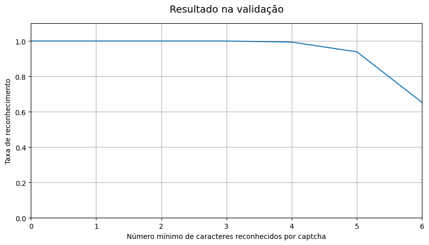

```python
def hit_rate(y_real: np.ndarray, y_pred: np.ndarray):# -> np.ndarray[np.float64]:
    assert y_real.shape[0] == y_pred.shape[0]
    n_samples = y_real.shape[0]
    num_hit_samples = np.zeros(OUTPUT_LENGTH + 1)
    for i in range(n_samples):
        sample_hits = 0
        for j in range(OUTPUT_LENGTH):
            if y_pred[i][j] == y_real[i][j]:
                sample_hits += 1
        num_hit_samples[sample_hits] += 1
    cumulative_hits = np.empty(OUTPUT_LENGTH + 1)
    cumulative_hits[OUTPUT_LENGTH] = num_hit_samples[OUTPUT_LENGTH]
    for i in range(OUTPUT_LENGTH - 1, -1, -1):
        cumulative_hits[i] = num_hit_samples[i] + cumulative_hits[i + 1]
    return cumulative_hits / n_samples

y_pred_val = model.predict(X_validation)
y_pred_val_lbl = process_output(y_pred_val)

plt.figure(figsize=(10, 5))
plt.plot(np.arange(0, 7), hit_rate(y_validation_labels, y_pred_val_lbl))
plt.ylim(0, 1.1)
plt.xlim(0, 6)
plt.grid()
plt.title("Resultado na validação", fontsize=14, pad=16)
plt.xlabel("Número mínimo de caracteres reconhecidos por captcha")
plt.ylabel("Taxa de reconhecimento");
```

# Teste das instâncias

```python
y_pred = model.predict(X_test)
y_pred_labels = process_output(y_pred)
```

## Resultados da classificação de 50 instâncias de teste:

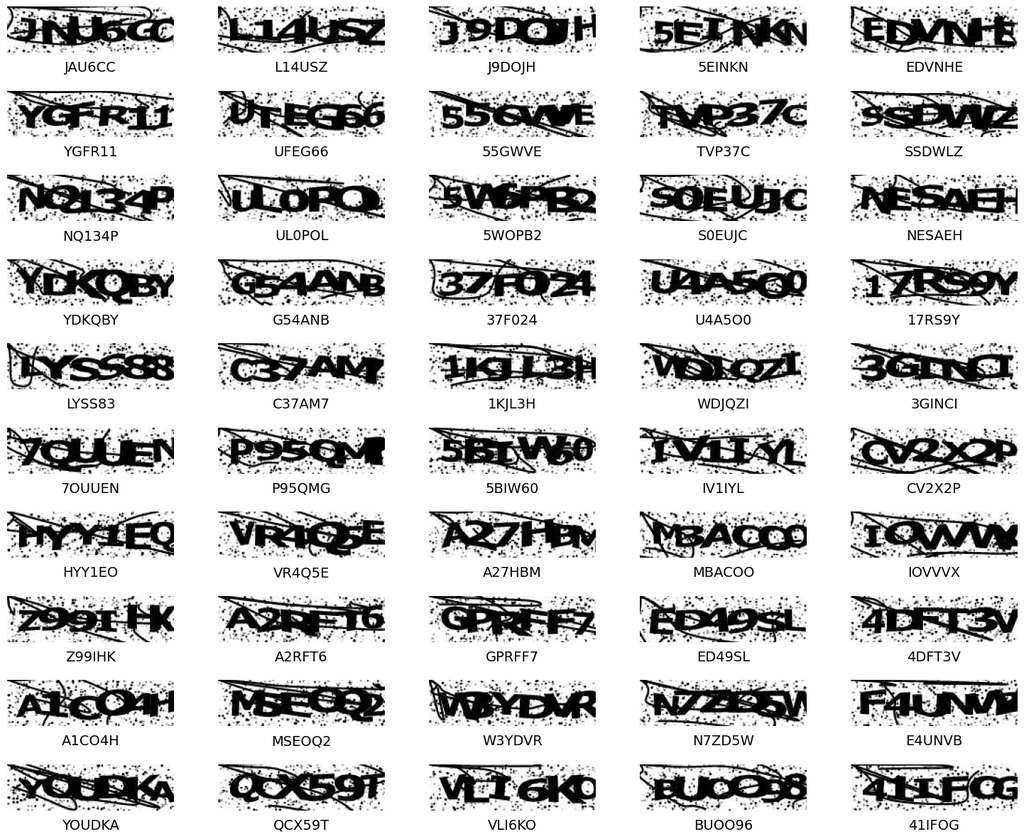

```python
fig, ax = plt.subplots(10, 5)
fig.set_figwidth(15)
fig.set_figheight(12)
fig.tight_layout()
for k, label in enumerate(y_pred_labels[:50]):
    i = k // 5
    j = k % 5
    ax[i, j].imshow(X_test[k, :, :], cmap="gray")
    ax[i, j].axis("off")
    ax[i, j].set_title(label, y=-0.4, pad=0, fontsize=14)
```

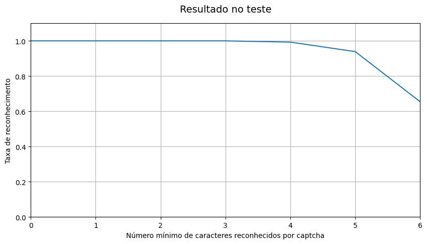

```python
plt.figure(figsize=(10, 5))
plt.plot(np.arange(0, 7), hit_rate(y_test_labels, y_pred_labels))
plt.ylim(0, 1.1)
plt.xlim(0, 6)
plt.grid()
plt.title("Resultado no teste", fontsize=14, pad=16)
plt.xlabel("Número mínimo de caracteres reconhecidos por captcha")
plt.ylabel("Taxa de reconhecimento");
```

# Conclusão

Algumas observações feitas durante o desenvolvimento foram que aumentar a capacidade da rede ao aumentar o número de camadas causou um impacto positivo no desempenho final, enquanto aumentar o número de neurônios apenas aumentou o tempo de treinamento, sem um impacto significativo no resultado final.

Após o treinamento, foi possível observar uma taxa de reconhecimento de aproximadamente 65% dos seis caracteres, 95% de cinco, e praticamente 100% de pelo menos quatro. Esse resultado só foi alcançado com 50 épocas na fase de treinamento, sendo que 30 épocas garantiram apenas 60% de reconhecimento de todos os caracteres. O resultado foi satisfatório considerando a rede desenvolvida e os dados de treino utilizados.